# Part II - (Exploration of Flight Dataset)

## by (BAMIGBOLA VICTOR)

## Investigation Overview

> In this investigation I want to look into the factors that contributed greatly on flight delay as well as cancellation. The main focus are on cancellation factors , delays variables of the dataset as well as unique carriers

## Dataset Overview

> The dataset is from Data Expo 2009. It comprises of flight operation details i.e Arrival and Departure of all flight within USA, starting from October 1987 to April 2008. We have the dataset divided into each year which can be downloaded on there website. There website address is as follows https://dataverse.harvard.edu/dataset.xhtml?persistentId=doi:10.7910/DVN/HG7NV7. However, for the sake of this analysis we would limit the dataset to 3 years which are from 2006 to 2008 due to how big the dataset his for the whole years.

### DISTRIBUTION OF CARRIER WITH HIGHEST CANCELLATION

## (Visualization 1)

> From the plot below we can see that MQ(Envoy Air), AA(American Airline) and OO(Sky West Airline )had the highest cancellation from other carrier which the reason for the cancellation of this top airline are due to the four cancellation code A,B,C,D which are Carrier, Weather, National Air System, Security respectively.

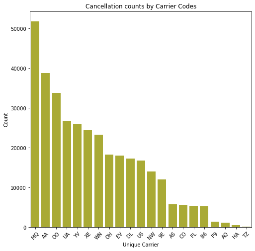

### DISTRIBUTION OF MOST COMMON REASONS FOR FLIGHT CANCELLATION

## (Visualization 2)

> As shown in graph below, it is obvious that A (Carrier) as well as B (Weather) has the height reason why flight are been cancelled

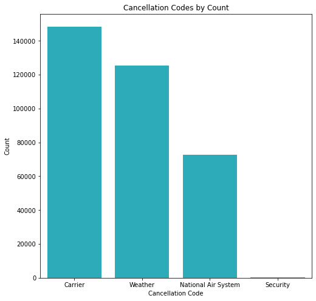

### CARRIER PRODUCTIVITY BY FLIGHT ARRIVAL TIME

## (Visualization 3)

> From the plot below we can see that the green color represent the total flight that arrived on time while the red represent the total flight that got delayed. Which implies the larger the red color the lower the productivity of the flight.

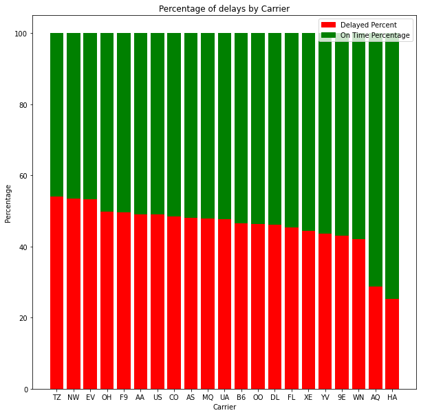

### TREND OF FLIGHT DELAY FACTOR BY MONTH TO MONTH

## (Visualization 4)

> Looking at the plot below we can see that Late_Aircraft_Delay and Weather has the highest effect on flight delay than any other delay factors

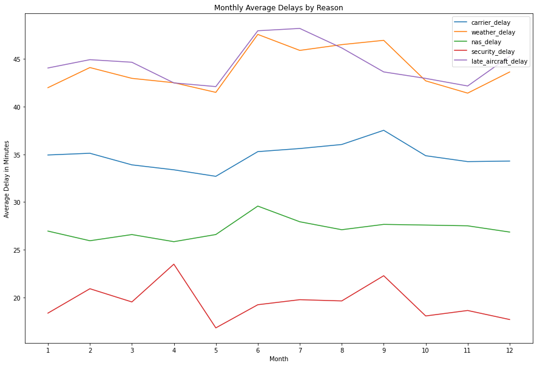

### TREND OF FLIGHT DELAY FACTORS BY YEAR TO YEAR

## (Visualization 5)

> Looking at the plot below we can see that both weather and late aircraft delay has the highest delay compared to other factors on all the years.

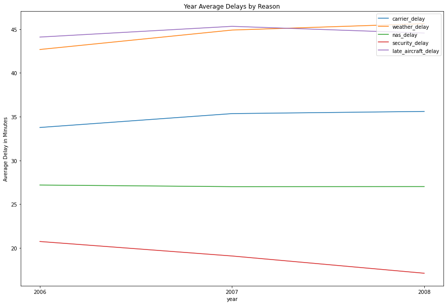